# SBC_pollution_China data analysis

## Data source

The data source of this dataset is:

- TFP_SBC_firm

### Variable name

The variables names and labels are the following:

|  | Variables | Labels | Types |
| --- | --- | --- | --- |
| 0 | id | id | object |
| 1 | OWNERSHIP | OWNERSHIP | object |
| 2 | year | year | int64 |
| 3 | geocode4_corr | geocode4_corr | int64 |
| 4 | industry | industry | int64 |
| 5 | occurence | occurence | int64 |
| 6 | tfp_OP | tfp_OP | float64 |
| 7 | tfp_OWNERSHIP | tfp_OWNERSHIP | float64 |
| 8 | polluted_thre | polluted_thre | object |
| 9 | cityen | cityen | object |
| 10 | Coastal | Coastal | bool |
| 11 | TCZ_c | TCZ_c | object |
| 12 | target_c | target_c | float64 |
| 13 | Period | Period | object |
| 14 | FE_c_i | FE_c_i | int64 |
| 15 | FE_t_i | FE_t_i | int64 |
| 16 | FE_t_c | FE_t_c | int64 |
| 17 | FE_c_i_o | FE_c_i_o | int64 |
| 18 | FE_t_o | FE_t_o | int64 |

# Analysis

## Load the data

It takes a will to upload the firm data, so we load it localy.

[output not shown]

# Table TFP

$$ TFP _{fi k t}=\alpha\left(\text { Period } \times \text { Target }_{i} \times \text { Polluting sectors }_{k} \right)+\nu_{i}+\lambda_{t}+\phi_{k}+\epsilon_{i k t} $$

## Test

For each category, proceed as follow:

1. Without Firm's FE
- Test 1
  - `target * polluted * period *ownership`
  - `target * polluted * period` FOR SOE
  - `target * polluted * period` FOR PRIVATE
  - FE: `cio + ct+ti+to` & `ci+ct+ti`
- Test 2
  - Similar to test 1, but filter `TCZ/No TCZ`
- Test 3
  - `target * period *ownership`
  - `target * period` FOR SOE
  - `target * period` FOR PRIVATE
  - FE: `cio + to+tc` & `c+i+t`
- Test 4
  - Similar to test 3, but filter `TCZ/No TCZ`
1. With Firm's FE
- Identical to `Without Firm's FE` but include `firm` fixed effect

### Without firm's fixed effect

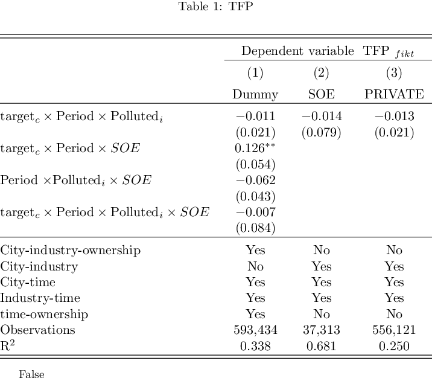

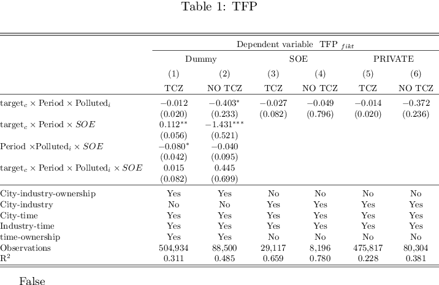

Remove `polluted sector`

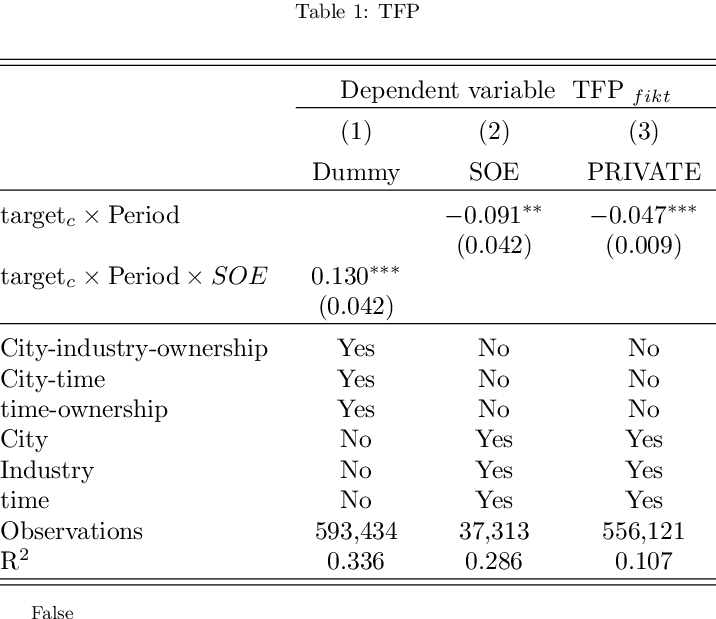

[figure not shown]

### With firm's fixed effect

```
Mon Apr 20 06:35:07 2020 finished centering model matrix
```

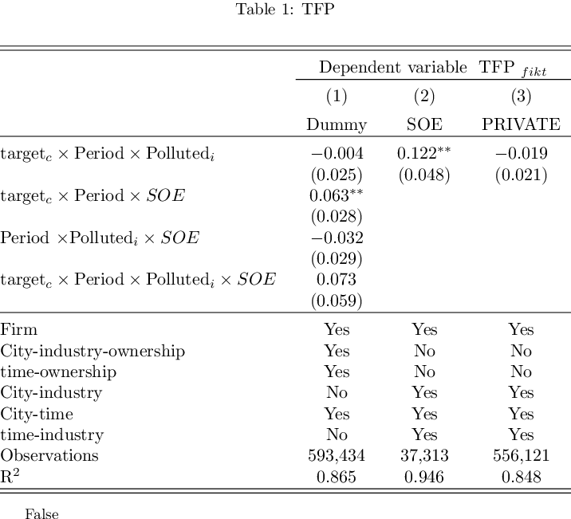

```
Mon Apr 20 07:51:46 2020 finished centering model matrix
```

[figure not shown]

```
Mon Apr 20 08:53:47 2020 finished centering model matrix
```

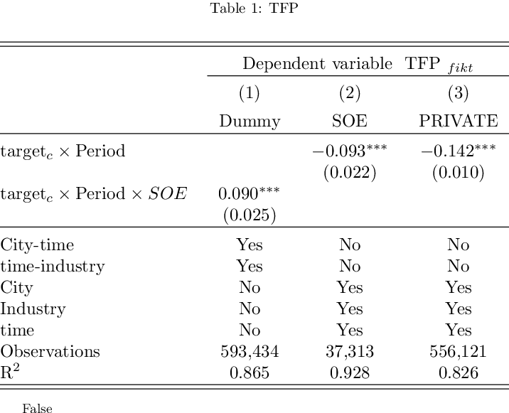

# Create Report

```
0
```